# Data Appendix

Mine Cetinkaya-Rundel

February 12, 2016

## Load data

```r
load("oww.RData")
```

## Data Dictionary

**Note:** The data dictionary is not yet complete, but there should be sufficient information here to give you an idea of how to create such a document.

- `year` - year
  - original variable name: `y0`

```
##   min   Q1 median   Q3  max     mean       sd      n missing
##  1983 1988   1994 2000 2008 1994.551 7.168429 125018       0
```

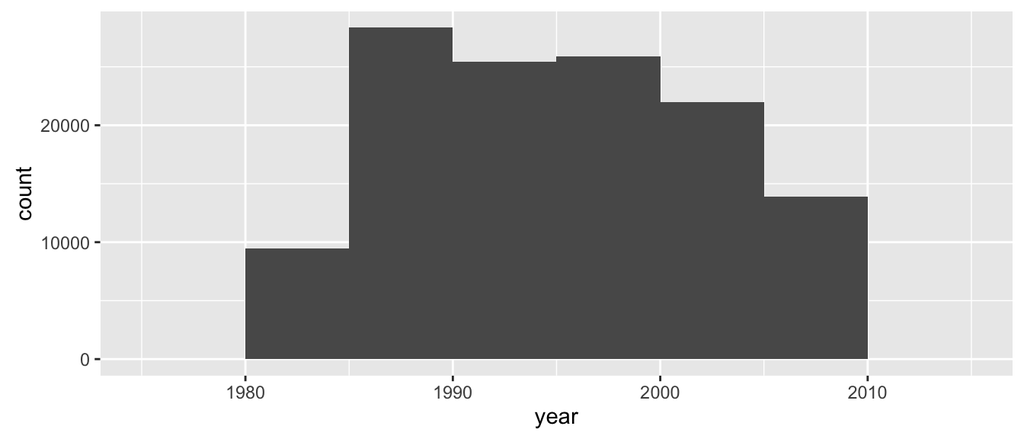

- `country_ILO` - country code (from ILO October Inquiry)
  - original variable name: `y1`

```
## Source: local data frame [171 x 2]
##
##    country_ILO   n()
##         (fctr) (int)
## 1           AG   525
## 2           AI   669
## 3           AN   327
## 4           AO   661
## 5           AR   951
## 6           AS   205
## 7           AT  2719
## 8           AU  2491
## 9           AZ   469
## 10          BB   999
## ..         ...   ...
```

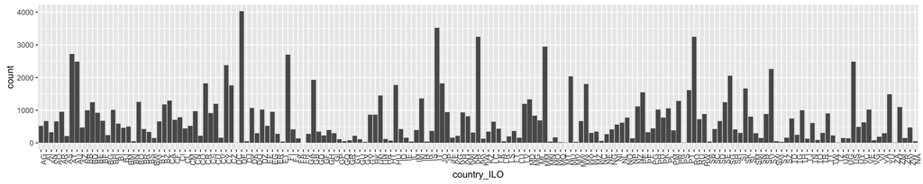

- `country_WDI` - country code (from World Development Indicators)
  - original variable name: `country`

```
## Source: local data frame [162 x 2]
##
##    country_WDI   n()
##         (fctr) (int)
## 1               3090
## 2          AGO   661
## 3          ANT   327
## 4          ARG   951
## 5          ASM   205
## 6          ATG   525
## 7          AUS  2491
## 8          AUT  2719
## 9          AZE   469
## 10         BDI   593
## ..         ...   ...
```

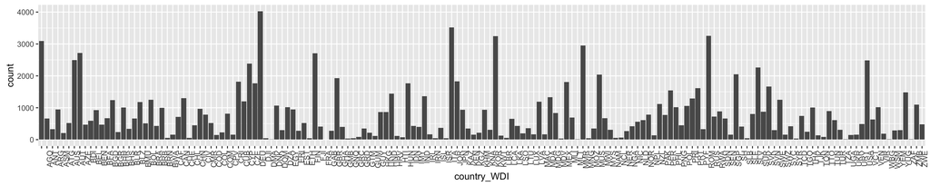

- `industry` - industry code (from ILO October Inquiry)
  - original variable name: `y3`

```
## Source: local data frame [49 x 2]
##
##    industry   n()
##      (fctr) (int)
## 1        AA  1321
## 2        AB  1016
## 3        AC  1117
## 4        AD   908
## 5        AE   589
## 6        BA  1155
## 7        BB  1611
## 8        BC  1169
## 9        CA  1761
## 10       CB   894
## ..      ...   ...
```

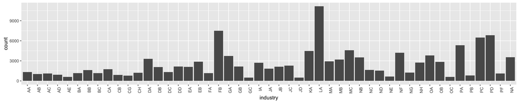

- `occupation` - occupation code (from ILO October Inquiry)
  - original variable name: `y4`

```
## Source: local data frame [161 x 2]
##
##    occupation   n()
##        (fctr) (int)
## 1           1   596
## 2           2   725
## 3           3   466
## 4           4   550
## 5           5   528
## 6           6   589
## 7           7   517
## 8           8   391
## 9           9   308
## 10         10   281
## ..        ...   ...
```

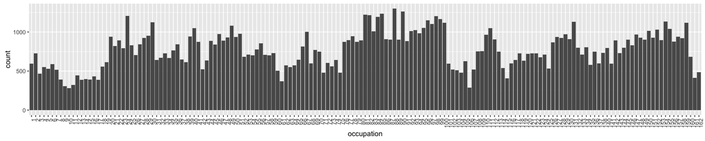

- `hw1` - hourly: standard data LCU

```
##        min       Q1   median       Q3      max     mean       sd     n
##  0.1278671 6.263736 23.99176 247.5634 543558.5 1149.671 10305.36 24620
##  missing
##   100398
```

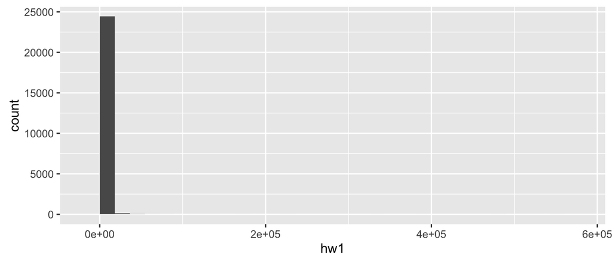

- `hw2wu` - hourly: country-specific calibration (uni) LCU

```
##        min       Q1   median       Q3      max     mean       sd     n
##  0.1278671 5.642932 17.35843 123.1081 543558.5 835.4699 8056.692 65502
##  missing
##    59516
```

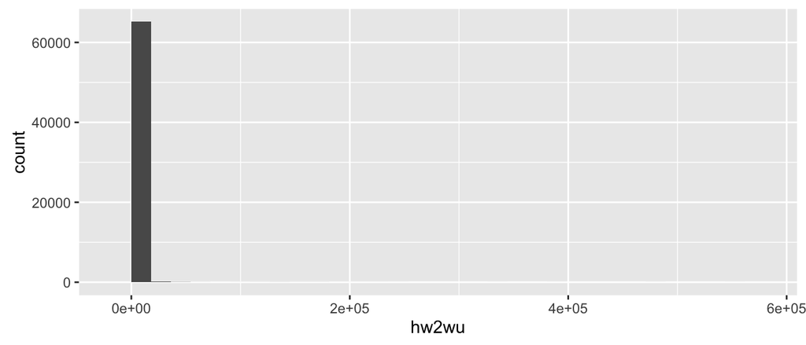

- `hw3wu` - hourly: country-specific calibration with imputation (uni) LCU

```
##         min       Q1   median       Q3     max     mean       sd      n
##  0.02123643 5.722178 17.51047 124.3542 1247703 2678.972 33136.69 125018
##  missing
##        0
```

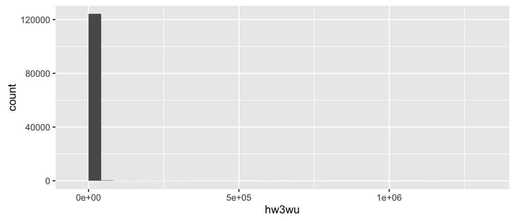

- `hw4wu` - hourly: uniform calibration (uni) LCU

```
##         min       Q1   median       Q3     max     mean       sd      n
##  0.02146009 5.672926 17.16973 126.8786 1247703 2553.423 31551.81 125018
##  missing
##        0
```

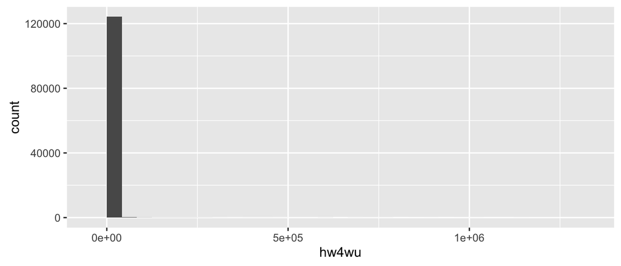

- `hw2wl` - hourly: country-specific calibration (lex) LCU

```
##        min       Q1   median       Q3      max     mean      sd     n
##  0.1278671 5.637579 17.35202 123.2009 543558.5 832.1777 8053.73 65502
##  missing
##    59516
```

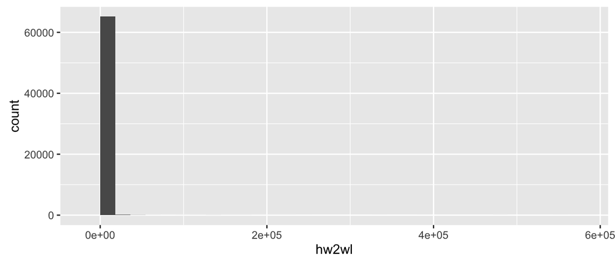

- `hw3wl` - hourly: country-specific calibration with imputation (lex) LCU

```
##         min      Q1   median       Q3     max     mean       sd      n
##  0.02123643 5.72132 17.50032 124.4121 1247703 2677.207 33136.41 125018
##  missing
##        0
```

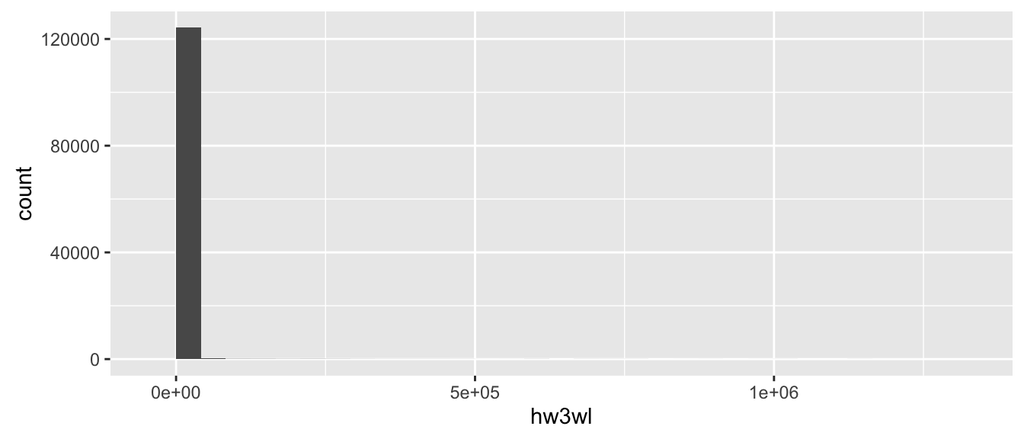

- `hw4wl` - hourly: uniform calibration (lex) LCU
- `hw1us` - hourly: standard data US$
- `hw2wuus` - hourly: country-specific calibration (uni) US$
- `hw3wuus` - hourly: country-specific calibration with imputation (uni) US$
- `hw4wuus` - hourly: uniform calibration (uni) US$
- `hw2wlus` - hourly: country-specific calibration (lex) US$
- `hw3wlus` - hourly: country-specific calibration with imputation (lex) US$
- `hw4wlus` - hourly: uniform calibration (lex) US$
- `mw1` - monthly: standard data LCU
- `mw2wu` - monthly: country-specific calibration (uni) LCU
- `mw3wu` - monthly: country-specific calibration with imputation (uni) LCU
- `mw4wu` - monthly: uniform calibration (uni) LCU
- `mw2wl` - monthly: country-specific calibration (lex) LCU
- `mw3wl` - monthly: country-specific calibration with imputation (lex) LCU
- `mw4wl` - monthly: uniform calibration (lex) LCU
- `mw1us` - monthly: standard data US$
- `mw2wuus` - monthly: country-specific calibration (uni) US$
- `mw3wuus` - monthly: country-specific calibration with imputation (uni) US$
- `mw4wuus` - monthly: uniform calibration (uni) US$
- `mw2wlus` - monthly: country-specific calibration (lex) US$
- `mw3wlus` - monthly: country-specific calibration with imputation (lex) US$
- `mw4wlus` - monthly: uniform calibration (lex) US$
- `curr` - currency as reported in ILO October Inquiry
- `exrt` - exchange rate: LCU per US$
- `conv`- conversion factor for wages in LCU
- `curr_conv` - currency used for conversion factor